# Práctica 2: Reflexión de la luz. Verificación experimental de los coeficientes de Fresnel.

## 1. Conceptos previos

*En grupo, discute las siguientes cuestiones:*

- ¿Cuáles son las leyes básicas de la reflexión? ¿Y de la refracción?
- ¿Cuándo la luz se refleja en un vidrio, qué % se de intensidad se refleja? ¿De qué depende este %?
- ¿Qué diferencias hay entre la luz natural y la luz polarizada? ¿Qué hace un filtro polarizador?

**NOTA:** en esta práctica nos focalizaremos única y exclusivamente en el fenómeno de reflexión.

## 2. Objetivos de la práctica

- Estudiar el coeficiente de reflexión en energías para un haz linealmente polarizado PARALELO al plano de incidencia.
- Determinar el ángulo de Brewster para el vidrio.
- Estudiar el giro que experimenta el ángulo azimutal de un haz linealmente poralizado tras una reflexión.

## 3. Fundamento teórico

**LEE DETENIDAMENTE ESTA SECCIÓN** antes de comenzar las mediciones. De lo contrario, será muy difícil llevar a cabo esta práctica...

### 3.1. Coeficientes de Fresnel

Cuando la luz se refleja/refracta en una superfice, el haz incidente, reflejado y refractado forman un único plano con la normal. Llamamos a este plano PLANO DE INCIDENCIA.

Por último, conviene recordar que mediremos los ángulos de los haces incidentes, reflejado refractado respecto a la normal. Cuando el haz incide de manera frontal a la interfase, $\theta_i=0$.

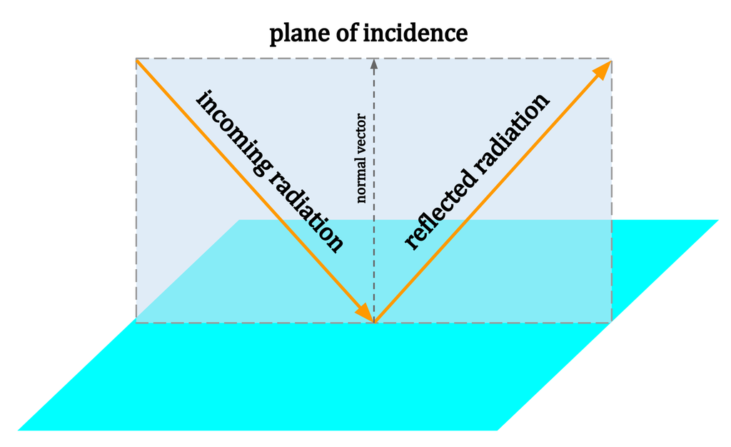

*Imagen tomada de https://mpo.im/tech-notes/polarisation-and-polarisers.*

A la hora de estudiar la reflexión (idem refracción), descomponemos el campo de un haz linealmente polarizado en la componente paralela al plano de incidencia ($E^\parallel$) y la componente perpendicular ($E^\perp$). Los subíndices $i$, $r$ y $t$ se refieren al haz incidente, reflejado y refractado (transmitido), respectivamente.

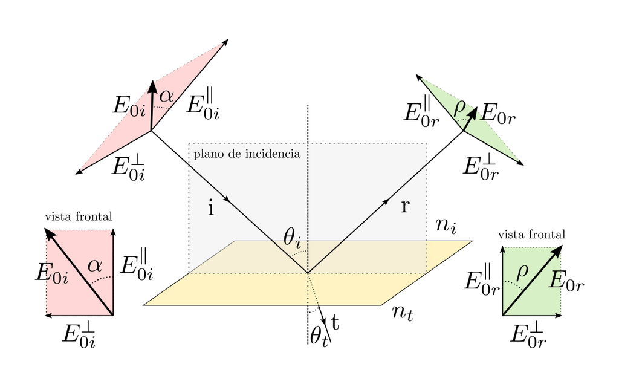

Tras la reflexión, la amplitud del campo ($E_0$) en cada componente sufre un cambio que depende del ángulo de incidencia ($\theta_i$) y los índices de refracción de cada medio ($n_i$, $n_t$). Se puede demostrar (ver apuntes de clase) que estos cambios pueden ser calculados a partir de los llamados *coeficientes de reflexión en amplitudes* de Fresnel:

$$r_\perp \equiv \frac{E_{0r}^\perp}{E_{0i}^\perp} = ... = \frac{n_i \cos\theta_i - n_t \cos\theta_t}{n_i \cos\theta_i + n_t \cos\theta_t}$$$$r_\parallel \equiv \frac{E_{0r}^\parallel}{E_{0i}^\parallel} = ... = \frac{n_t \cos\theta_i - n_i \cos\theta_t}{n_t \cos\theta_i + n_i \cos\theta_t},$$

donde a su vez el ángulo refractado $\theta_t$ viene determinado a través de la ley de Snell, $n_i \sin\theta_i = n_t \sin\theta_t$.

Generalmente no medimos amplitudes, sino energías o irradiancias. En este caso, se puede demostrar que la fracción de potencia reflejada viene dada por el coeficiente de reflexión en energías, $$R \equiv \frac{\mathrm{potencia\;reflejada}}{\mathrm{potencia\;incidente}} = \frac{I_r}{I_i} = r^2,$$ la cual vale para un haz linealmente polarizado en el plano de incidencia ($R_\parallel = r_\parallel^2$) o perpendicular a este ($R_\perp = r_\perp^2$).

- **NOTA**: para el caso de la reflexión, es equivalente trabajar con potencias o irradiancias (estas últimas son las que medimos con el polímetro). Si quisiéramos estudiar el coeficiente de transmisión para el haz refractado, habría que hacerlo con más cuidado (ver apuntes de clase).

### 3.2. Ángulo de Brewster

A la hora de estudiar los coeficientes, se puede ver que existe un ángulo de incidencia no trivial, $\theta_i = \theta_B$, para el cual $r_\parallel=0$, $r_\perp\neq0$ (y no al revés). Esto tiene varias implicaciones:

- Si hacemos incidir luz linealmente polarizada en el plano de incidencia, no existe haz reflejado, y toda la luz se transmite.
- Si hacemos incidir luz natural (que podemos siempre descomponer en componentes $\parallel$ y $\perp$) con ese ángulo, la luz reflejada solo tiene componente perpendicular, es decir, se refleja polarizada.

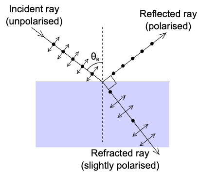

*Imagen tomada de Wikipedia.*

Se puede demostrar (ver apuntes de clase) que este ángulo se obtiene a partir de la siguiente relación: $$\tan\theta_B = \frac{n_t}{n_i}.$$

### 3.3. Ángulo azimutal

Los coeficientes de reflexión en amplitudes de Fresnel nos dicen que las componentes paralelas y perpendiculares de un haz no necesariamente se reflejan en la misma proporción. Esto tiene un efecto directo: *el plano de oscilación puede cambiar tras una reflexión*.

El **ángulo azimutal** es el ángulo que forma el plano de oscilación con el plano de incidencia. Llamremos $\alpha$ al ángulo azimutal del haz incidente, y $\rho$ al ángulo azimutal del haz reflejado. Se puede demostrar que:

$$\tan\rho = \frac{r_\perp}{r_\parallel} \tan\alpha = ... = -\frac{\cos(\theta_i-\theta_t)}{\cos(\theta_i+\theta_t)}\tan\alpha.$$

- **NOTA:** Esta fórmula predice que, para incidencia normal ($\theta_i = \theta_t=0$), hay un cambio de signo en el ángulo azimutal, $\rho=-\alpha$.

## 4. Materiales

*Identifica, en tu montaje, los siguientes elementos:*

- Láser de He-Ne.
- Dos filtros polarizadores con goniómetro (medidor de ángulos).
- Vidrio semicircular montado en goniómetro.
- Fotómetro.
- Polímetro.
- Plataforma de altura regulable.

*Para la última parte ("Observación del fenómeno de polarización por reflexión") necesitas, además:*

- Dos polarizadores grandes.

**PRECAUCIONES:**

- No mires directamente al láser.
- A la hora de medir con el fotómetro, asegúrate que el haz incide en el centro del sensor.
- Cuidado con eventuales golpes al montaje, pueden descalibrar el experimento fácilmente.
- Deja todo el material recogido y limpio al finalizar.

## 5. Mediciones

### 5.1. Calibrado

1. Coloca el láser sobre el soporte, asegurando que el campo eléctrico oscile en un plano paralelo al suelo.
2. Enciende y alinea el láser para que atraviese el goniómetro desde 0° hasta 180°.
3. Ajusta el goniómetro a 90° y coloca el vidrio semicircular en el centro, con la cara plana centrada y paralela al haz.
4. Mueve el vidrio para visualizar toda la trayectoria del láser sobre la superficie plana (aparecerá una linea punteada ligeramente), especialmente para ángulos de incidencia grandes.
5. Pon el goniómetro en 0° y ajusta el láser para que el rayo reflejado regrese por la abertura del láser, logrando incidencia normal (0°).

*Antes de seguir, discuta en grupo las siguientes cuestiones.*

- ¿Cuál es el plano de incidencia del experimento?
- ¿Por qué crees que es más interesante estudiar $R_\parallel$ que $R_\perp$?
- ¿Podemos estimar, mediante una observación rápida, el ángulo de Brewster en este experimento, $\theta_B$?

### 5.2. Medida del coeficiente de reflexión $R_\parallel$ y determinación del ángulo de Brewster.

[figure not shown]

*Montaje para la determinación del coeficiente de reflexión de Fresnel y el ángulo de Brewster. Algunos elementos podrían diferir del tuyo.**

En esta parte nos centraremos en estudiar la componente paralela al plano de incidencia. Tomaremos el índice de refreacción del aire $n_i=1$, y llamaremos $n$ al índice de refracción del vidrio.

1. Coloca un polarizador delante del láser para asegurar que el haz está linealmente polarizado y paralelo al plano de incidencia.
2. Diseña un experimento para medir $R_\parallel(\theta_i)$. Toma datos cada 5°. En un intervalo de $10°$ que contenga al ángulo de Brewster, toma datos cada 1°.
3. Determina el ángulo de Brewster experimentalmente, y a partir de ahí calcula el índice de refracción del vidrio $n$.
4. Representa los datos experimentales junto con la curva teórica de $R_\parallel(\theta_i)$ (para esta deberás utilizar el valor de $n$ calculado anteriormente).
- **NOTA:** La función $R_\parallel(\theta_i)$ require calcular $\theta_t$ a partir de la ley de Snell.

### 5.3. Determinación del ángulo azimutal del haz reflejado.

[figure not shown]

1. Coloca el polarizador delante del láser a 45°, de forma que el ángulo azimutal del haz incidente sea precisamente $\alpha=45$°.
2. Cuando la luz se refleja, el ángulo azimutal puede cambiar. Usarás un segundo polarizador con goniómetro y el fotómetro para determinar el ángulo azimutal del haz reflejado, $\rho$.
3. Diseña un experimento para medir $\rho$ en función del ángulo de incidencia $\theta_i$, empezando en $\theta_i=10$°. Como antes, toma datos cada 5°, y cada 1° en un intervalo de 10° que contenga al ángulo de Brewster.
- **PRECAUCIONES**:
  - Ten cuidado con darle la vuelta a uno de los medidores de ángulos (intenta que estén siempre a favor del haz o en contra del haz).
  - Ten en cuenta que los polarizadores tienen el 0 apuntando hacia arriba. No obstante, queremos medir los ángulos respecto al plano de incidencia (paralelo al suelo del laboratorio). Esto puede tenerse en cuenta después de haber tomado los datos, tomando el complementario.
  - Ten en cuenta que el cuadrante donde estamos midiendo la posición angular es relevante (implica un cambio de signo).
  - Una forma de comprobar que estamos midiendo bien los ángulos es que, si todo está bien colocado, para ángulos pequeños ($\theta_i \lesssim 10$°), $\rho\simeq -\alpha$.
- **NOTA:**
  - No es necesario que anotes la intensidad del fotómetro. Usarás esta solo para identificar donde está el máximo (o mínimo) de intensidad transmitida por el polarizador.
  - A la hora de deteminar la dirección de oscilación del campo con el fotómetro, se puede trabajar con intensidades máximas transmitidas, o mínimas y luego rotar 90°. Esta última es menos directa, pero tiene una ventaja... ¿cuál?
4. Representa los datos experimentales junto con la curva teórica de $\rho(\theta_i)$ (para esta deberás utilizar el valor de $n$ calculado anteriormente).
- **NOTA:** La función $\rho(\theta_i)$ require calcular $\theta_t$ a partir de la ley de Snell.
5. ¿Cuál es el valor de $\rho(\theta_i=\theta_B)$? A partir de los resultados experimentales, vuelve a determinar el ángulo de Brewster. Es posible que tengas que utilizar una interpolación.

### 5.4. Observación del fenómeno de polarización por reflexión

*Para esta parte no será necesario la toma de datos, harás solo un estudio cualitativo del fenómeno.*

1. Observa el reflejo de una lámpara del pasillo sobre el suelo. Identifica el plano de incidencia en este caso.
2. Para ángulos de incidencia cercanos al ángulo de Brewster, la luz reflejada estará polarizada. Discute con tus compañeros: ¿en qué dirección estará polarizada la luz reflejada, paralela o perpendicular al suelo? ¿Por qué?
3. **Verificación experimental:**
   - Observa el reflejo a través de un polarizador grande.
   - Gira el polarizador hasta que el reflejo sea mínimo.
   - Comenta con tus compañeros si la dirección del eje del polarizador (marcado sobre el filtro) coincide con la esperada.
4. **Incidencia normal:**
   - Repite la observación cuando el ángulo de incidencia es cercano a 0°.
   - ¿Qué ocurre con la polarización de la luz reflejada en este caso? ¿Se observa alguna diferencia respecto al caso anterior?
5. Resume brevemente la fenomenología observada y relaciónala con lo estudiado anteriormente.

**RECUERDA:**

- No mires directamente al láser.
- A la hora de medir con el fotómetro, asegúrate que el haz incide en el centro del sensor.
- Cuidado con eventuales golpes al montaje, pueden descalibrar el experimento fácilmente.
- Deja todo el material recogido y limpio al finalizar.